# Disease-X-Patient-Outcome-Analytics

```python
import sqlite3
import pandas as pd
import numpy as np
import matplotlib.pyplot as plt
import seaborn as sns
import warnings

warnings.filterwarnings("ignore")
```

```python
conn = sqlite3.connect("Disease X.db")
table_1 = "disease_x_raw"
disease_x_raw_df = pd.read_sql_query(f"SELECT * FROM {table_1};", conn)
disease_x_raw_df.head()
```

|  | case_id | date_infection | date_hospitalization | date_outcome | outcome | age | age_unit | age_years | age_cat | age_cat5 | ... | wt_kg | ht_cm | ct_blood | fever | chills | cough | aches | vomit | temp | bmi |
| --- | --- | --- | --- | --- | --- | --- | --- | --- | --- | --- | --- | --- | --- | --- | --- | --- | --- | --- | --- | --- | --- |
| 0 | 5fe599 | 2014-05-15 | 2014-05-08 | None | None | 2.0 | years | 2.0 | 0-4 | 0-4 | ... | 27.0 | 48.0 | 22.0 | no | no | yes | no | yes | 36.8 | 117.187500 |
| 1 | b8812a | 2014-05-20 | 2014-05-04 | None | None | 18.0 | years | 18.0 | 15-19 | 15-19 | ... | 41.0 | 135.0 | 23.0 | no | no | no | no | no | 36.8 | 22.496571 |
| 2 | 893f25 | 2014-05-22 | 2014-05-18 | 2014-05-29 | Recover | 3.0 | years | 3.0 | 0-4 | 0-4 | ... | 36.0 | 71.0 | 23.0 | no | no | yes | no | yes | 36.9 | 71.414402 |
| 3 | be99c8 | 2014-05-23 | 2014-05-03 | 2014-05-24 | Recover | 16.0 | years | 16.0 | 15-19 | 15-19 | ... | 56.0 | 116.0 | 21.0 | no | no | yes | no | yes | 37.6 | 41.617122 |
| 4 | 07e3e8 | 2014-05-29 | 2014-05-22 | 2014-06-01 | Recover | 16.0 | years | 16.0 | 15-19 | 15-19 | ... | 47.0 | 87.0 | 21.0 | None | None | None | None | None | 37.3 | 62.095389 |

5 rows × 23 columns

```python
disease_x_raw_df.info()
```

```
<class 'pandas.core.frame.DataFrame'>
RangeIndex: 3675 entries, 0 to 3674
Data columns (total 23 columns):
 #   Column                Non-Null Count  Dtype
---  ------                --------------  -----
 0   case_id               3675 non-null   object
 1   date_infection        3675 non-null   object
 2   date_hospitalization  3675 non-null   object
 3   date_outcome          3052 non-null   object
 4   outcome               2841 non-null   object
 5   age                   3620 non-null   float64
 6   age_unit              3675 non-null   object
 7   age_years             3620 non-null   float64
 8   age_cat               3620 non-null   object
 9   age_cat5              3620 non-null   object
 10  hospital              3675 non-null   object
 11  lon                   3675 non-null   float64
 12  lat                   3675 non-null   float64
 13  wt_kg                 3675 non-null   float64
 14  ht_cm                 3675 non-null   float64
 15  ct_blood              3675 non-null   float64
 16  fever                 3524 non-null   object
 17  chills                3524 non-null   object
 18  cough                 3524 non-null   object
 19  aches                 3524 non-null   object
 20  vomit                 3524 non-null   object
 21  temp                  3586 non-null   float64
 22  bmi                   3675 non-null   float64
dtypes: float64(9), object(14)
memory usage: 660.5+ KB
```

```python
disease_x_raw_df["age"].isna().sum()
```

```
55
```

**Observation** - The age column contains mixed units (months and years), so I chose to use the standardized age_years column for consistency in analysis.

```python
disease_x_raw_df[disease_x_raw_df["age"] != disease_x_raw_df["age_years"]][
    ["age", "age_unit", "age_years"]
]
```

|  | age | age_unit | age_years |
| --- | --- | --- | --- |
| 146 | NaN | years | NaN |
| 270 | 24.0 | months | 2.000000 |
| 291 | NaN | months | NaN |
| 341 | NaN | years | NaN |
| 349 | 7.0 | months | 0.583333 |
| ... | ... | ... | ... |
| 2963 | NaN | years | NaN |
| 2986 | NaN | years | NaN |
| 2994 | NaN | years | NaN |
| 3126 | NaN | years | NaN |
| 3261 | NaN | years | NaN |

75 rows × 3 columns

**Observation** - The date_infection and date_hospital columns are in object format, so I am converting them to datetime format for consistency and easier analysis.

```python
date_columns = ["date_infection", "date_hospitalization", "date_outcome"]
for col in date_columns:
    disease_x_raw_df[col] = pd.to_datetime(disease_x_raw_df[col])

disease_x_raw_df.info()
```

```
<class 'pandas.core.frame.DataFrame'>
RangeIndex: 3675 entries, 0 to 3674
Data columns (total 23 columns):
 #   Column                Non-Null Count  Dtype
---  ------                --------------  -----
 0   case_id               3675 non-null   object
 1   date_infection        3675 non-null   datetime64[ns]
 2   date_hospitalization  3675 non-null   datetime64[ns]
 3   date_outcome          3052 non-null   datetime64[ns]
 4   outcome               2841 non-null   object
 5   age                   3620 non-null   float64
 6   age_unit              3675 non-null   object
 7   age_years             3620 non-null   float64
 8   age_cat               3620 non-null   object
 9   age_cat5              3620 non-null   object
 10  hospital              3675 non-null   object
 11  lon                   3675 non-null   float64
 12  lat                   3675 non-null   float64
 13  wt_kg                 3675 non-null   float64
 14  ht_cm                 3675 non-null   float64
 15  ct_blood              3675 non-null   float64
 16  fever                 3524 non-null   object
 17  chills                3524 non-null   object
 18  cough                 3524 non-null   object
 19  aches                 3524 non-null   object
 20  vomit                 3524 non-null   object
 21  temp                  3586 non-null   float64
 22  bmi                   3675 non-null   float64
dtypes: datetime64[ns](3), float64(9), object(11)
memory usage: 660.5+ KB
```

```python
table_2 = "inpatient_days_raw"
inpatient_days_raw_df = pd.read_sql_query(f"SELECT * FROM {table_2};", conn)
inpatient_days_raw_df.head()
```

|  | Facility | Bed_Census_Calendar_Year | Bed_Census_Month_ID | pdays |
| --- | --- | --- | --- | --- |
| 0 | Rosewood Hospital Center | 2014 | 201401 | 3070 |
| 1 | Rosewood Hospital Center | 2014 | 201402 | 2798 |
| 2 | Rosewood Hospital Center | 2014 | 201403 | 3060 |
| 3 | Rosewood Hospital Center | 2014 | 201404 | 2872 |
| 4 | Rosewood Hospital Center | 2014 | 201405 | 3074 |

```python
inpatient_days_raw_df.info()
```

```
<class 'pandas.core.frame.DataFrame'>
RangeIndex: 1120 entries, 0 to 1119
Data columns (total 4 columns):
 #   Column                    Non-Null Count  Dtype
---  ------                    --------------  -----
 0   Facility                  1120 non-null   object
 1   Bed_Census_Calendar_Year  1120 non-null   int64
 2   Bed_Census_Month_ID       1120 non-null   int64
 3   pdays                     1120 non-null   int64
dtypes: int64(3), object(1)
memory usage: 35.1+ KB
```

```python
# Converting Bed_Census_Month_ID into date time object
inpatient_days_raw_df["Bed_Census_Month_ID"] = pd.to_datetime(
    inpatient_days_raw_df["Bed_Census_Month_ID"], format="%Y%m"
)
inpatient_days_raw_df.info()
```

```
<class 'pandas.core.frame.DataFrame'>
RangeIndex: 1120 entries, 0 to 1119
Data columns (total 4 columns):
 #   Column                    Non-Null Count  Dtype
---  ------                    --------------  -----
 0   Facility                  1120 non-null   object
 1   Bed_Census_Calendar_Year  1120 non-null   int64
 2   Bed_Census_Month_ID       1120 non-null   datetime64[ns]
 3   pdays                     1120 non-null   int64
dtypes: datetime64[ns](1), int64(2), object(1)
memory usage: 35.1+ KB
```

The rates are commonly calculated by calendar year or quarter. Quarter 1 is from Jan to Mar, Quarter 2 is from Apr to Jun, Quarter 3 is from Jul to Sep, and Quarter 4 is from Oct to Dec.

Question: What is the disease X overall rate for Quarter 3 of 2014?`

```python
# Filter data for Quarter 3 of 2014 (July to September)
q3_cases_df = disease_x_raw_df[
    (disease_x_raw_df["date_infection"].dt.year == 2014)
    & (disease_x_raw_df["date_infection"].dt.month.isin([7, 8, 9]))
]

# Filter inpatient days for Quarter 3 of 2014
q3_inpatient_days_df = inpatient_days_raw_df[
    (inpatient_days_raw_df["Bed_Census_Month_ID"].dt.year == 2014)
    & (inpatient_days_raw_df["Bed_Census_Month_ID"].dt.month.isin([7, 8, 9]))
]
total_inpatient_days_q3 = q3_inpatient_days_df["pdays"].sum()

# Calculate disease rate for Q3 2014
rate_q3 = (q3_cases_df.shape[0] / total_inpatient_days_q3) * 10000
print(f"Disease X overall rate for Q3 2014: {rate_q3:.2f} per 10,000")
```

```
Disease X overall rate for Q3 2014: 58.24 per 10,000
```

Disease X cases are classified based on the source of acquisition. A case is classified as “Healthcare-acquired” if the disease is identified more than 5 days after the patient is admitted to the hospital, and as “Community-acquired” if the disease is identified within 5 days or less of admission.

Question: Using the datasets, calculate the Healthcare-acquired rate and Community-acquired rate for disease X, separately for Quarter 4 of 2014. Be sure to define how you will calculate each rate and explain your methodology

```python
disease_x_raw_df["days_to_infection"] = (
    disease_x_raw_df["date_infection"] - disease_x_raw_df["date_hospitalization"]
).dt.days


disease_x_raw_df["source_acquisition"] = disease_x_raw_df["days_to_infection"].apply(
    lambda x: "Healthcare-acquired" if x > 5 else "Community-acquired"
)
```

```python
disease_x_raw_df.head()
```

|  | case_id | date_infection | date_hospitalization | date_outcome | outcome | age | age_unit | age_years | age_cat | age_cat5 | ... | ct_blood | fever | chills | cough | aches | vomit | temp | bmi | days_to_infection | source_acquisition |
| --- | --- | --- | --- | --- | --- | --- | --- | --- | --- | --- | --- | --- | --- | --- | --- | --- | --- | --- | --- | --- | --- |
| 0 | 5fe599 | 2014-05-15 | 2014-05-08 | NaT | None | 2.0 | years | 2.0 | 0-4 | 0-4 | ... | 22.0 | no | no | yes | no | yes | 36.8 | 117.187500 | 7 | Healthcare-acquired |
| 1 | b8812a | 2014-05-20 | 2014-05-04 | NaT | None | 18.0 | years | 18.0 | 15-19 | 15-19 | ... | 23.0 | no | no | no | no | no | 36.8 | 22.496571 | 16 | Healthcare-acquired |
| 2 | 893f25 | 2014-05-22 | 2014-05-18 | 2014-05-29 | Recover | 3.0 | years | 3.0 | 0-4 | 0-4 | ... | 23.0 | no | no | yes | no | yes | 36.9 | 71.414402 | 4 | Community-acquired |
| 3 | be99c8 | 2014-05-23 | 2014-05-03 | 2014-05-24 | Recover | 16.0 | years | 16.0 | 15-19 | 15-19 | ... | 21.0 | no | no | yes | no | yes | 37.6 | 41.617122 | 20 | Healthcare-acquired |
| 4 | 07e3e8 | 2014-05-29 | 2014-05-22 | 2014-06-01 | Recover | 16.0 | years | 16.0 | 15-19 | 15-19 | ... | 21.0 | None | None | None | None | None | 37.3 | 62.095389 | 7 | Healthcare-acquired |

5 rows × 25 columns

```python
Healthcare_Acquired_q3 = disease_x_raw_df[
    disease_x_raw_df["source_acquisition"] == "Healthcare-acquired"
][
    (disease_x_raw_df["date_infection"].dt.year == 2014)
    & (disease_x_raw_df["date_infection"].dt.month.isin([7, 8, 9]))
]

rate_q3 = (Healthcare_Acquired_q3.shape[0] / total_inpatient_days_q3) * 10000
print(f"Disease X Healthcare_Acquired rate for Q3 2014: {rate_q3:.2f} per 10,000")
```

```
Disease X Healthcare_Acquired rate for Q3 2014: 45.99 per 10,000
```

```python
Community_Acquired_q3 = disease_x_raw_df[
    disease_x_raw_df["source_acquisition"] == "Community-acquired"
][
    (disease_x_raw_df["date_infection"].dt.year == 2014)
    & (disease_x_raw_df["date_infection"].dt.month.isin([7, 8, 9]))
]

rate_q3 = (Community_Acquired_q3.shape[0] / total_inpatient_days_q3) * 10000
print(f"Disease X Community_Acquired rate for Q3 2014: {rate_q3:.2f} per 10,000")
```

```
Disease X Community_Acquired rate for Q3 2014: 12.25 per 10,000
```

**Definitions & Methodology**

- Healthcare-acquired rate: Cases identified >5 days after admission per 10,000 inpatient days.
- Community-acquired rate: Cases identified ≤5 days after admission per 10,000 inpatient days.

Classification:

- Cases are classified using the difference between date_infection and date_hospitalization (days_to_infection).

Rate Formula:

- Rate = (Number of Cases / Total Inpatient Days) × 10,000.

Results for Q3 2014:

- Healthcare-acquired rate: 45.99 per 10,000 inpatient days.
- Community-acquired rate: 12.25 per 10,000 inpatient days.

Purpose:

- This method ensures fair comparison across hospitals and time periods by normalizing case counts.

The rates for disease X are also calculated at the hospital level to assess facility performance.

Question:

Calculate the Healthcare-acquired rate for disease X separately for Military Hospital and Port Hospital in Quarter 4 of 2014. Ensure to specify how you would compute the rates for each hospital and explain your methodology.

```python
q4_cases_df = disease_x_raw_df[
    (disease_x_raw_df["date_infection"].dt.year == 2014)
    & (disease_x_raw_df["date_infection"].dt.month.isin([10, 11, 12]))
]
q4_cases_df.head()
```

|  | case_id | date_infection | date_hospitalization | date_outcome | outcome | age | age_unit | age_years | age_cat | age_cat5 | ... | ct_blood | fever | chills | cough | aches | vomit | temp | bmi | days_to_infection | source_acquisition |
| --- | --- | --- | --- | --- | --- | --- | --- | --- | --- | --- | --- | --- | --- | --- | --- | --- | --- | --- | --- | --- | --- |
| 179 | 46bed2 | 2014-10-01 | 2014-09-27 | 2014-10-12 | Death | 20.0 | years | 20.0 | 20-29 | 20-24 | ... | 22.0 | no | yes | yes | no | yes | 37.0 | 24.910767 | 4 | Community-acquired |
| 180 | 2adcc8 | 2014-10-01 | 2014-09-28 | NaT | Recover | 1.0 | years | 1.0 | 0-4 | 0-4 | ... | 23.0 | None | None | None | None | None | 37.2 | 138.888889 | 3 | Community-acquired |
| 181 | 7f3916 | 2014-10-02 | 2014-08-31 | 2014-10-12 | Recover | 2.0 | years | 2.0 | 0-4 | 0-4 | ... | 22.0 | no | no | yes | no | no | 36.5 | 67.639729 | 32 | Healthcare-acquired |
| 182 | 747ece | 2014-10-01 | 2014-09-24 | 2014-10-12 | Recover | 4.0 | years | 4.0 | 0-4 | 0-4 | ... | 22.0 | no | no | no | no | no | 36.2 | 74.666667 | 7 | Healthcare-acquired |
| 183 | 4086d0 | 2014-10-01 | 2014-09-26 | NaT | Death | 4.0 | years | 4.0 | 0-4 | 0-4 | ... | 21.0 | None | None | None | None | None | 36.7 | 108.875740 | 5 | Community-acquired |

5 rows × 25 columns

```python
for hospital in ["Military Hospital", "Port Hospital"]:

    hospital_cases_df = q4_cases_df[q4_cases_df["hospital"] == hospital]
    healthcare_acquired_cases = hospital_cases_df[
        hospital_cases_df["source_acquisition"] == "Healthcare-acquired"
    ].shape[0]

    hospital_inpatient_days_df = inpatient_days_raw_df[
        (inpatient_days_raw_df["Facility"] == hospital)
        & (
            (inpatient_days_raw_df["Bed_Census_Month_ID"].dt.month.isin([10, 11, 12]))
            & (inpatient_days_raw_df["Bed_Census_Month_ID"].dt.year == 2014)
        )
    ]
    total_inpatient_days = hospital_inpatient_days_df["pdays"].sum()

    healthcare_acquired_rate = (
        (healthcare_acquired_cases / total_inpatient_days) * 10000
        if total_inpatient_days > 0
        else 0
    )

    print(f"{hospital}:")
    print(f"  Healthcare-acquired Cases: {healthcare_acquired_cases}")
    print(f"  Total Inpatient Days: {total_inpatient_days}")
    print(f"  Healthcare-acquired Rate: {healthcare_acquired_rate:.2f} per 10,000\n")
```

```
Military Hospital:
  Healthcare-acquired Cases: 186
  Total Inpatient Days: 30861
  Healthcare-acquired Rate: 60.27 per 10,000

Port Hospital:
  Healthcare-acquired Cases: 403
  Total Inpatient Days: 51877
  Healthcare-acquired Rate: 77.68 per 10,000
```

**Definition & Methodology:**

- Healthcare-acquired rate is the number of Healthcare-acquired cases per 10,000 inpatient days for a hospital.

Filter Cases:

- Extract Q4 2014 cases for each hospital and count Healthcare-acquired cases based on the source_acquisition column.

Filter Inpatient Days:

- Sum the total inpatient days (pdays) for each hospital in Q4 2014.

Rate Formula:

- Rate = (Number of Cases / Total Inpatient Days) × 10,000.

Purpose:

- Standardizes infection rates for comparison between hospitals, normalized by inpatient days.

**Insights**

- Higher Infection Rate at Port Hospital: The Healthcare-acquired rate at Port Hospital (77.68 per 10,000) is significantly higher than at Military Hospital (60.27 per 10,000), indicating a potential need for improved infection control measures at Port Hospital.
- Disparity in Case Volume: Port Hospital recorded more than double the number of Healthcare-acquired cases (403 vs. 186) compared to Military Hospital, despite having only 68% more inpatient days, suggesting a higher infection burden at Port Hospital.

Question: Calculate the 95% confidence interval for the Healthcare-acquired rates of disease X for Military Hospital and Port Hospital in Quarter 4 of 2014 (as per Q3). What conclusions can you draw by comparing the confidence intervals of the two hospitals?

```python
disease_x_q4_2014 = disease_x_raw_df[
    (pd.to_datetime(disease_x_raw_df["date_infection"]).dt.year == 2014)
    & (pd.to_datetime(disease_x_raw_df["date_infection"]).dt.month.isin([10, 11, 12]))
]

healthcare_acquired = disease_x_q4_2014[
    disease_x_q4_2014["source_acquisition"] == "Healthcare-acquired"
]

military_cases = healthcare_acquired[
    healthcare_acquired["hospital"] == "Military Hospital"
]
port_cases = healthcare_acquired[healthcare_acquired["hospital"] == "Port Hospital"]

military_days = inpatient_days_raw_df[
    (inpatient_days_raw_df["Facility"] == "Military Hospital")
    & (inpatient_days_raw_df["Bed_Census_Month_ID"].dt.year == 2014)
    & (inpatient_days_raw_df["Bed_Census_Month_ID"].dt.month.isin([10, 11, 12]))
]["pdays"].sum()

port_days = inpatient_days_raw_df[
    (inpatient_days_raw_df["Facility"] == "Port Hospital")
    & (inpatient_days_raw_df["Bed_Census_Month_ID"].dt.year == 2014)
    & (inpatient_days_raw_df["Bed_Census_Month_ID"].dt.month.isin([10, 11, 12]))
]["pdays"].sum()


print("Number of Military cases:", military_cases.shape[0])
print("Number of Military days:", military_days)
print("Number of Port cases:", port_cases.shape[0])
print("Number of Port days:", port_days)

military_rate = (military_cases.shape[0] / military_days) * 10000
port_rate = (port_cases.shape[0] / port_days) * 10000

def confidence_interval(rate, total_days, z=1.96):
    p = rate / 10000
    error = z * np.sqrt((p * (1 - p)) / total_days)
    lower = (p - error) * 10000
    upper = (p + error) * 10000
    return lower, upper


military_ci = confidence_interval(military_rate, military_days)
port_ci = confidence_interval(port_rate, port_days)

print(
    f"\n\nMilitary Hospital Rate: {military_rate:.2f} cases per 10,000 inpatient days"
)
print(f"95% CI for Military Hospital: ({military_ci[0]:.2f}, {military_ci[1]:.2f})")

print(f"Port Hospital Rate: {port_rate:.2f} cases per 10,000 inpatient days")
print(f"95% CI for Port Hospital: ({port_ci[0]:.2f}, {port_ci[1]:.2f})")
```

```
Number of Military cases: 186
Number of Military days: 30861
Number of Port cases: 403
Number of Port days: 51877


Military Hospital Rate: 60.27 cases per 10,000 inpatient days
95% CI for Military Hospital: (51.63, 68.91)
Port Hospital Rate: 77.68 cases per 10,000 inpatient days
95% CI for Port Hospital: (70.13, 85.24)
```

**Conclusion & Insights:**

- Lower Infection Rate at Military Hospital: Military Hospital has a significantly lower healthcare-acquired rate (60.27/10,000 inpatient days) compared to Port Hospital (77.68/10,000 inpatient days).
- Statistically Significant Difference: The non-overlapping confidence intervals (Military: 51.63–68.91, Port: 70.13–85.24) indicate a statistically significant difference in infection rates.
- Port Hospital's Higher Risk: Port Hospital’s higher rate suggests a potential gap in infection prevention practices compared to Military Hospital.
- Efficiency at Military Hospital: Despite fewer inpatient days (30,861 vs. 51,877), Military Hospital managed to keep infection numbers low (186 cases vs. 403 cases).
- Actionable Priority: Port Hospital should prioritize evaluating and improving infection control measures to reduce its higher healthcare-acquired infection rate.

Infection Prevention and Control Data Analysts often use the epidemiological week case numbers to visualize trends. An epidemiological week runs from Sunday to Saturday. For example, 2014 Week 17 spans from Sunday, April 20, 2014, to Saturday, April 26, 2014.

Question:

Generate a stacked bar chart showing the weekly number of confirmed disease X cases by source of acquisition (Healthcare-acquired vs. Community-acquired) for the period between 2014 Week 17 and 2015 Week 17. What trend do you observe in the bar chart?

```python
def addlabels(x, y):
    for i in range(len(x)):
        plt.text(i, y[i], y[i], ha="center")
```

[figure not shown]

```python
disease_x_raw_df["year_week"] = (
    disease_x_raw_df["date_infection"].dt.year.astype(str)
    + " Week "
    + disease_x_raw_df["date_infection"].dt.isocalendar().week.astype(str)
)

filtered_df = disease_x_raw_df[
    (disease_x_raw_df["year_week"] >= "2014 Week 17")
    & (disease_x_raw_df["year_week"] <= "2015 Week 17")
]


weekly_counts = (
    filtered_df.groupby(["year_week", "source_acquisition"])
    .size()
    .unstack(fill_value=0)
)


weekly_counts = weekly_counts.reindex(
    sorted(weekly_counts.index, key=lambda x: (int(x.split()[0]), int(x.split()[2])))
)


fig, ax = plt.subplots(figsize=(20, 10))
bars = weekly_counts.plot(
    kind="bar",
    stacked=True,
    figsize=(20, 10),
    width=0.8,
    color=["#1f77b4", "#ff7f0e"],
    ax=ax,
)


for x_index, (week, row) in enumerate(weekly_counts.iterrows()):
    cumulative_height = 0
    for category, value in row.items():
        if value > 0:
            y = cumulative_height + value / 2
            ax.text(x_index, y, int(value), ha="center", va="center", fontsize=8)
            cumulative_height += value

plt.title(
    "Weekly Number of Disease X Cases by Source of Acquisition (2014 Week 17 - 2015 Week 17)",
    fontsize=16,
)
plt.xlabel("Year-Week", fontsize=14)
plt.ylabel("Number of Cases", fontsize=14)


plt.xticks(
    rotation=45, fontsize=10, ha="right"
)
plt.subplots_adjust(bottom=0.2)


plt.legend(title="Source of Acquisition", fontsize=12)
plt.tight_layout()


plt.show()
```

**Observation:**

- The majority of Disease X cases are classified as healthcare-acquired, indicating that the disease is primarily spreading within healthcare settings after 5 days of admission. This suggests the need for stricter infection control measures in hospitals.

Clear Outbreak Pattern:

- There is a sharp rise in cases (both healthcare-acquired and community-acquired) starting around 2014 Week 30, peaking around 2014 Week 39–44, and then gradually declining into 2015. This period aligns with the flu season, which typically occurs in late fall and winter, suggesting that Disease X may have intensified during this time due to increased hospitalizations and weakened immunity among patients.

Decline After Peak:

- The sharp decline in cases after the peak suggests effective public health interventions or infection control measures were implemented, particularly in healthcare settings, to combat the spread during and after the flu season.
- By linking the outbreak to the flu season, it emphasizes the importance of heightened infection control during periods of increased hospitalizations and seasonal illnesses.

The proportion of disease X cases by age group provides valuable insight into how the disease affects different age populations. Question: For Healthcare-acquired cases only, generate a graph to show the weekly proportion of cases by age group between 2014 Week 17 and 2015 Week 17. Use age_cat to define the age groups. What trend do you observe from the graph?

[figure not shown]

```python
healthcare_acquired_df = disease_x_raw_df[
    disease_x_raw_df["source_acquisition"] == "Healthcare-acquired"
]


healthcare_acquired_df["year_week"] = (
    healthcare_acquired_df["date_infection"].dt.year.astype(str)
    + " Week "
    + healthcare_acquired_df["date_infection"].dt.isocalendar().week.astype(str)
)

filtered_df = healthcare_acquired_df[
    (healthcare_acquired_df["year_week"] >= "2014 Week 17")
    & (healthcare_acquired_df["year_week"] <= "2015 Week 17")
]

weekly_counts_age = (
    filtered_df.groupby(["year_week", "age_cat"]).size().unstack(fill_value=0)
)


weekly_counts_age = weekly_counts_age.reindex(
    sorted(
        weekly_counts_age.index, key=lambda x: (int(x.split()[0]), int(x.split()[2]))
    )
)


weekly_age_group_counts = weekly_counts_age.copy()
weekly_proportions = weekly_age_group_counts.div(
    weekly_age_group_counts.sum(axis=1), axis=0
)

fig, (ax1, ax2) = plt.subplots(1, 2, figsize=(24, 10), sharey=False)

weekly_counts_age.plot(kind="bar", stacked=True, width=0.8, cmap="tab20", ax=ax1)


for x_index, (week, row) in enumerate(weekly_counts_age.iterrows()):
    cumulative_height = 0
    for idx, (category, value) in enumerate(row.items()):
        if value > 0:
            y = cumulative_height + value / 2
            ax1.text(x_index, y, int(value), ha="center", va="center", fontsize=8)
            cumulative_height += value


ax1.set_title(
    "Weekly Number of Healthcare-acquired Cases by Age Group",
    fontsize=16,
)
ax1.set_xlabel("Year-Week", fontsize=14)
ax1.set_ylabel("Number of Cases", fontsize=14)
ax1.tick_params(axis="x", rotation=45)
ax1.legend(title="Age Group", fontsize=10, bbox_to_anchor=(1.05, 1), loc="upper left")
ax1.set_xticks(range(len(weekly_counts_age.index)))
ax1.set_xticklabels(weekly_counts_age.index, rotation=45, ha="right")
ax1.grid(False)

weekly_proportions.plot(kind="bar", stacked=True, width=0.8, cmap="tab20", ax=ax2)

ax2.set_title(
    "Weekly Proportion of Healthcare-acquired Cases by Age Group",
    fontsize=16,
)
ax2.set_xlabel("Year-Week", fontsize=14)
ax2.set_ylabel("Proportion of Cases", fontsize=14)
ax2.tick_params(axis="x", rotation=45)
ax2.legend(title="Age Group", fontsize=10, bbox_to_anchor=(1.05, 1), loc="upper left")
ax2.set_xticks(range(len(weekly_proportions.index)))
ax2.set_xticklabels(weekly_proportions.index, rotation=45, ha="right")
ax2.grid(False)


plt.tight_layout()
plt.subplots_adjust(bottom=0.25)
plt.show()
```

**Observations:**

Conduct a statistical hypothesis test to compare the mean age of Healthcare-acquired confirmed cases and Community-acquired confirmed cases. Provide a step-by-step explanation of your approach, including:

1. The null and alternative hypotheses.
2. The statistical test you will use.
3. The interpretation of your results.

```python
healthcare_acquired = disease_x_raw_df[
    disease_x_raw_df["source_acquisition"] == "Healthcare-acquired"
]["age_years"].copy(deep=True)
community_acquired = disease_x_raw_df[
    disease_x_raw_df["source_acquisition"] == "Community-acquired"
]["age_years"].copy(deep=True)

healthcare_acquired = pd.to_numeric(healthcare_acquired, errors="coerce")
community_acquired = pd.to_numeric(community_acquired, errors="coerce")
```

```python
print("Healthcare-acquired size:", healthcare_acquired.size)
print("Community-acquired size:", community_acquired.size)


print("Healthcare-acquired missing values:", healthcare_acquired.isnull().sum())
print("Community-acquired missing values:", community_acquired.isnull().sum())


print("Healthcare-acquired variance:", healthcare_acquired.var())
print("Community-acquired variance:", community_acquired.var())
```

```
Healthcare-acquired size: 2884
Community-acquired size: 791
Healthcare-acquired missing values: 47
Community-acquired missing values: 8
Healthcare-acquired variance: 162.00211489630638
Community-acquired variance: 150.44797456482362
```

Observation - Dropped null values from the age_years column in a copy of the original data to ensure accurate computations without affecting subsequent analysis steps.

```python
healthcare_acquired.dropna(inplace=True)
community_acquired.dropna(inplace=True)
```

```python
from scipy.stats import ttest_ind


t_stat, p_value_ttest = ttest_ind(
    healthcare_acquired, community_acquired, equal_var=True
)


print("Two-Sample T-Test Results")
print(f"T-statistic: {t_stat:.4f}, P-value: {p_value_ttest:.4f}")
if p_value_ttest < 0.05:
    print(
        "Interpretation: Reject the null hypothesis. There is a significant difference in the mean age between healthcare-acquired and community-acquired cases.\n"
    )
else:
    print(
        "Interpretation: Fail to reject the null hypothesis. There is no significant difference in the mean age between healthcare-acquired and community-acquired cases.\n"
    )
```

```
Two-Sample T-Test Results
T-statistic: 0.8604, P-value: 0.3896
Interpretation: Fail to reject the null hypothesis. There is no significant difference in the mean age between healthcare-acquired and community-acquired cases.
```

**Step-By-Step Explanation** -

Data Splitting:

- Divided the dataset into two groups: Healthcare-acquired and Community-acquired cases based on the source_acquisition column.

Handling Null Values:

- Dropped null values from the age_years column in a copy of the original data to ensure accurate computations without affecting subsequent analysis steps.

Checking Variability:

- Verified the variance of both groups to confirm that the data is not constant.

Hypothesis Setup:

- Null Hypothesis : The mean age is the same for both groups.
- Alternative Hypothesis : The mean age differs between the two groups.

Two-Sample T-Test:

- Test Used: Two-sample t-test.
- Reason: Compares the means of two independent groups to detect significant differences.

Results Interpretation:

- The p-value (0.3896) is greater than the significance level (0.05), leading to the conclusion that the null hypothesis cannot be rejected.
- There is no significant difference in the mean age between Healthcare-acquired and Community-acquired cases.

What are the assumptions of the statistical test used? How would you check these assumptions, and do you find any violation of the assumptions? Please provide detailed steps for checking each assumption

```python
from scipy.stats import shapiro, levene


healthcare_normality = shapiro(healthcare_acquired)
community_normality = shapiro(community_acquired)

print("Shapiro-Wilk Test for Normality:")
print(f"Healthcare-acquired: p-value = {healthcare_normality.pvalue}")
if healthcare_normality.pvalue < 0.05:
    print(
        "Interpretation: The age data for healthcare-acquired cases does not follow a normal distribution.\n"
    )
else:
    print(
        "Interpretation: The age data for healthcare-acquired cases follows a normal distribution.\n"
    )

print(f"Community-acquired: p-value = {community_normality.pvalue}")
if community_normality.pvalue < 0.05:
    print(
        "Interpretation: The age data for community-acquired cases does not follow a normal distribution.\n"
    )
else:
    print(
        "Interpretation: The age data for community-acquired cases follows a normal distribution.\n"
    )
```

```
Shapiro-Wilk Test for Normality:
Healthcare-acquired: p-value = 2.4072200064210013e-38
Interpretation: The age data for healthcare-acquired cases does not follow a normal distribution.

Community-acquired: p-value = 5.394794083770993e-20
Interpretation: The age data for community-acquired cases does not follow a normal distribution.
```

### Observation

its not a normal distribution as p-value is < 0.05 significance value

```python
levene_stat, levene_pvalue = levene(healthcare_acquired, community_acquired)

print(
    f"Levene's Test for Equal Variances: Statistic={levene_stat:.4f}, P-value={levene_pvalue:.4f}"
)
if levene_pvalue < 0.05:
    print(
        "Interpretation: The variances of the two groups are significantly different. The assumption of equal variances is violated.\n"
    )
else:
    print(
        "Interpretation: The variances of the two groups are not significantly different. The assumption of equal variances is satisfied.\n"
    )
```

```
Levene's Test for Equal Variances: Statistic=0.1522, P-value=0.6964
Interpretation: The variances of the two groups are not significantly different. The assumption of equal variances is satisfied.
```

**Assumptions of the Statistical Test (Two-Sample T-Test )**:

Independence:

- The two groups (Healthcare-acquired and Community-acquired) must consist of independent observations.

Normality:

- The data in both groups should be approximately normally distributed.

Equality of Variances:

- The variances of the two groups should be equal (homoscedasticity)

**Assumptions and Checks**:

Independence:

- Check: Ensure observations are independent and belong to mutually exclusive groups.
- Finding: Assumption satisfied as patients are classified into distinct groups.

Normality:

- Test: Shapiro-Wilk test for both groups.
- Result: Both groups failed the normality test
- Conclusion: Normality assumption is violated.

Equality of Variances:

- Test: Levene’s test to compare variances.
- Result: p-value = 0.6964 (fail to reject).

Conclusion: Assumption of equal variances is satisfied.

How would you evaluate the statistical test used ? What other tests, methods, or techniques could you use to compare the age distribution between the Healthcare-acquired group and the Community-acquired group? Provide step-by-step details of the alternative test(s) and explain why they might be appropriate.

```python
from scipy.stats import mannwhitneyu

# Mann-Whitney U Test
mann_whitney_test = mannwhitneyu(
    healthcare_acquired, community_acquired, alternative="two-sided"
)

print("\nMann-Whitney U Test:")
print(f"U-statistic = {mann_whitney_test.statistic}")
print(f"p-value = {mann_whitney_test.pvalue}")


alpha = 0.05
if mann_whitney_test.pvalue < alpha:
    print(
        "\nResult: Reject the null hypothesis. There is a significant difference in the distributions of age between Healthcare-acquired and Community-acquired cases."
    )
else:
    print(
        "\nResult: Fail to reject the null hypothesis. There is no significant difference in the distributions of age between Healthcare-acquired and Community-acquired cases."
    )
```

```
Mann-Whitney U Test:
U-statistic = 1128110.5
p-value = 0.5007335505636317

Result: Fail to reject the null hypothesis. There is no significant difference in the distributions of age between Healthcare-acquired and Community-acquired cases.
```

#### Reason for Evaluating:

- The two-sample t-test assumes normality, which was violated for both groups, making it less reliable for comparing their means.

Alternative Test: Mann-Whitney U Test:

- Reason: Does not assume normality and compares the distributions of two independent groups.

Hypotheses:

- Null Hypothesis: The distributions of age are the same for both groups.
- Alternative Hypothesis: The distributions of age differ between the two groups.

Result: U-statistic = 1,128,110.5, p-value = 0.5007.

- Fail to reject Null Hypothesis: No significant difference in age distributions between Healthcare-acquired and Community-acquired cases.

Conclusion:

- The Mann-Whitney U test is preferred when normality assumptions are violated, ensuring a valid comparison of distributions.

The Infection Prevention and Control Epidemiology Manager wants to determine if there is a significant difference in the mortality proportion between the Healthcare-acquired and Community-acquired groups. Question:

1. What are the mortality proportions in the Healthcare-acquired group and the Community-acquired group?
2. Is there a significant difference between the proportions? Provide step-by-step details of how you would calculate the proportions and test for significance.

```python
from statsmodels.stats.proportion import proportions_ztest

healthcare_group = disease_x_raw_df[
    disease_x_raw_df["source_acquisition"] == "Healthcare-acquired"
]
community_group = disease_x_q4_2014.loc[
    disease_x_q4_2014["source_acquisition"] == "Community-acquired"
]

healthcare_deaths = healthcare_group[healthcare_group["outcome"] == "Death"].shape[0]
community_deaths = community_group[community_group["outcome"] == "Death"].shape[0]

healthcare_total = healthcare_group.shape[0]
community_total = community_group.shape[0]

healthcare_mortality = healthcare_deaths / healthcare_total
community_mortality = community_deaths / community_total

print(f"Healthcare-acquired Mortality Proportion: {healthcare_mortality:.4f}")
print(f"Community-acquired Mortality Proportion: {community_mortality:.4f}")


count = [healthcare_deaths, community_deaths]
no_of_obs = [healthcare_total, community_total]

z_stat, p_value = proportions_ztest(count, no_of_obs)
print(f"Proportion Z-Test: Z-statistic = {z_stat:.4f}, P-value = {p_value:.4f}")

alpha = 0.05
if p_value < alpha:
    print(
        "Result: Reject the null hypothesis. There is a significant difference in mortality proportions."
    )
else:
    print(
        "Result: Fail to reject the null hypothesis. No significant difference in mortality proportions."
    )
```

```
Healthcare-acquired Mortality Proportion: 0.4324
Community-acquired Mortality Proportion: 0.4904
Proportion Z-Test: Z-statistic = -2.1047, P-value = 0.0353
Result: Reject the null hypothesis. There is a significant difference in mortality proportions.
```

### Test for Significant Difference:

**Method**:

- Used a two-proportion z-test to compare mortality proportions between the two groups.
- Null Hypothesis : The mortality proportions are equal for both groups.
- Alternative Hypothesis : The mortality proportions are significantly different between the groups.

**Steps**:

- Count the number of deaths and total cases for each group.
- Calculate mortality proportions (deaths/totaldeaths / totaldeaths/total).
- Perform a z-test using proportions_ztest() with counts and totals from both groups.

**Results**: Z-statistic = −2.1047 | P-value = 0.0353

**Interpretation**: Since the p-value (0.0353) is less than the significance level (0.05), we reject the null hypothesis.

#### Insights

Length of Stay (LOS) refers to the amount of time a patient spends in a healthcare facility and is an important metric in public health, healthcare management, and research. The Infection Prevention and Control Epidemiology Manager wants to determine which variables are important predictors of the Length of Stay for disease X cases. Question:

1. First, create the response variable LOS (Length of Stay).
2. Build a multivariate linear regression model using the following predictors: age_years, wt_kg, ht_cm, bmi, ct_blood, fever, chills, cough, aches, vomit, temp, and source of acquisition (Healthcare-acquired/Community-acquired).
3. Do you find any important predictors for LOS?
4. How do you interpret the coefficient estimate for the predictor source of acquisition?
5. How would you evaluate the model performance? Please provide step-by-step details for each part of the analysis

```python
disease_x_raw_df["LOS"] = (
    disease_x_raw_df["date_outcome"] - disease_x_raw_df["date_hospitalization"]
).dt.days
disease_x_raw_df
```

|  | case_id | date_infection | date_hospitalization | date_outcome | outcome | age | age_unit | age_years | age_cat | age_cat5 | ... | chills | cough | aches | vomit | temp | bmi | days_to_infection | source_acquisition | year_week | LOS |
| --- | --- | --- | --- | --- | --- | --- | --- | --- | --- | --- | --- | --- | --- | --- | --- | --- | --- | --- | --- | --- | --- |
| 0 | 5fe599 | 2014-05-15 | 2014-05-08 | NaT | None | 2.0 | years | 2.0 | 0-4 | 0-4 | ... | no | yes | no | yes | 36.8 | 117.187500 | 7 | Healthcare-acquired | 2014 Week 20 | NaN |
| 1 | b8812a | 2014-05-20 | 2014-05-04 | NaT | None | 18.0 | years | 18.0 | 15-19 | 15-19 | ... | no | no | no | no | 36.8 | 22.496571 | 16 | Healthcare-acquired | 2014 Week 21 | NaN |
| 2 | 893f25 | 2014-05-22 | 2014-05-18 | 2014-05-29 | Recover | 3.0 | years | 3.0 | 0-4 | 0-4 | ... | no | yes | no | yes | 36.9 | 71.414402 | 4 | Community-acquired | 2014 Week 21 | 11.0 |
| 3 | be99c8 | 2014-05-23 | 2014-05-03 | 2014-05-24 | Recover | 16.0 | years | 16.0 | 15-19 | 15-19 | ... | no | yes | no | yes | 37.6 | 41.617122 | 20 | Healthcare-acquired | 2014 Week 21 | 21.0 |
| 4 | 07e3e8 | 2014-05-29 | 2014-05-22 | 2014-06-01 | Recover | 16.0 | years | 16.0 | 15-19 | 15-19 | ... | None | None | None | None | 37.3 | 62.095389 | 7 | Healthcare-acquired | 2014 Week 22 | 10.0 |
| ... | ... | ... | ... | ... | ... | ... | ... | ... | ... | ... | ... | ... | ... | ... | ... | ... | ... | ... | ... | ... | ... |
| 3670 | 4799df | 2015-04-20 | 2015-04-05 | 2015-04-26 | Death | 7.0 | years | 7.0 | 5-9 | 5-9 | ... | no | yes | no | yes | NaN | 88.734568 | 15 | Healthcare-acquired | 2015 Week 17 | 21.0 |
| 3671 | bbf39f | 2015-04-19 | 2015-03-28 | 2015-04-19 | Death | 5.0 | years | 5.0 | 5-9 | 5-9 | ... | yes | yes | no | yes | NaN | 108.131488 | 22 | Healthcare-acquired | 2015 Week 16 | 22.0 |
| 3672 | 3da96a | 2015-04-20 | 2015-04-14 | 2015-05-20 | Recover | 13.0 | years | 13.0 | 10-14 | 10-14 | ... | no | no | no | yes | NaN | 26.058354 | 6 | Healthcare-acquired | 2015 Week 17 | 36.0 |
| 3673 | 76d8fe | 2015-04-22 | 2015-04-16 | 2015-05-06 | Recover | 7.0 | years | 7.0 | 5-9 | 5-9 | ... | no | no | no | yes | NaN | 50.204783 | 6 | Healthcare-acquired | 2015 Week 17 | 20.0 |
| 3674 | 2068d6 | 2015-04-30 | 2015-04-20 | 2015-05-02 | Death | 7.0 | years | 7.0 | 5-9 | 5-9 | ... | no | no | no | yes | NaN | 42.779512 | 10 | Healthcare-acquired | 2015 Week 18 | 12.0 |

3675 rows × 27 columns

Note: When calculating Length of Stay (LOS) by subtracting date_hospitalization from date_outcome, any missing value (NaN) in either column will result in the LOS being recorded as NaN.

```python
required_features = [
    "age_years",
    "wt_kg",
    "ht_cm",
    "bmi",
    "ct_blood",
    "fever",
    "chills",
    "cough",
    "aches",
    "vomit",
    "temp",
    "source_acquisition",
    "LOS",
]
```

```python
disease_x_raw_df["date_outcome"] = pd.to_datetime(
    disease_x_raw_df["date_outcome"], errors="coerce"
)
disease_x_raw_df["date_hospitalization"] = pd.to_datetime(
    disease_x_raw_df["date_hospitalization"], errors="coerce"
)

print("num LOS nans", disease_x_raw_df["LOS"].isna().sum())
disease_data = disease_x_raw_df.dropna(subset=["LOS"]).copy(
    deep=True
)
predictors = [
    "age_years",
    "wt_kg",
    "ht_cm",
    "bmi",
    "ct_blood",
    "fever",
    "chills",
    "cough",
    "aches",
    "vomit",
    "temp",
    "source_acquisition_Healthcare-acquired",
]
response = "LOS"


Data = pd.get_dummies(disease_data, columns=["source_acquisition"], drop_first=True)
binary_columns = ["fever", "chills", "cough", "aches", "vomit"]
for col in binary_columns:
    Data[col] = Data[col].map({"yes": 1, "no": 0})


Data["source_acquisition_Healthcare-acquired"] = Data[
    "source_acquisition_Healthcare-acquired"
].astype(int)
```

```
num LOS nans 623
```

```python
Data[predictors].isna().sum()
```

```
age_years                                  46
wt_kg                                       0
ht_cm                                       0
bmi                                         0
ct_blood                                    0
fever                                     124
chills                                    124
cough                                     124
aches                                     124
vomit                                     124
temp                                       74
source_acquisition_Healthcare-acquired      0
dtype: int64
```

```python
Data.shape
```

```
(3052, 27)
```

```python
X = Data[predictors]
y = Data[response]
```

```python
X.describe()
```

|  | age_years | wt_kg | ht_cm | bmi | ct_blood | fever | chills | cough | aches | vomit | temp | source_acquisition_Healthcare-acquired |
| --- | --- | --- | --- | --- | --- | --- | --- | --- | --- | --- | --- | --- |
| count | 3006.000000 | 3052.000000 | 3052.000000 | 3052.000000 | 3052.000000 | 2928.000000 | 2928.000000 | 2928.000000 | 2928.000000 | 2928.000000 | 2978.000000 | 3052.000000 |
| mean | 15.832557 | 52.338467 | 124.623853 | 46.749436 | 21.220183 | 0.805328 | 0.190574 | 0.862705 | 0.093921 | 0.498975 | 38.552384 | 0.784076 |
| std | 12.587387 | 18.534150 | 49.353733 | 53.191458 | 1.703914 | 0.396016 | 0.392821 | 0.344217 | 0.291768 | 0.500084 | 0.973879 | 0.411529 |
| min | 0.000000 | -10.000000 | 8.000000 | -600.000000 | 16.000000 | 0.000000 | 0.000000 | 0.000000 | 0.000000 | 0.000000 | 35.200000 | 0.000000 |
| 25% | 6.000000 | 41.000000 | 91.000000 | 24.489796 | 20.000000 | 1.000000 | 0.000000 | 1.000000 | 0.000000 | 0.000000 | 38.200000 | 1.000000 |
| 50% | 13.000000 | 54.000000 | 129.000000 | 32.275417 | 22.000000 | 1.000000 | 0.000000 | 1.000000 | 0.000000 | 0.000000 | 38.800000 | 1.000000 |
| 75% | 23.000000 | 66.000000 | 158.000000 | 49.984357 | 22.000000 | 1.000000 | 0.000000 | 1.000000 | 0.000000 | 1.000000 | 39.200000 | 1.000000 |
| max | 84.000000 | 111.000000 | 295.000000 | 816.326531 | 26.000000 | 1.000000 | 1.000000 | 1.000000 | 1.000000 | 1.000000 | 40.700000 | 1.000000 |

```python
median_values = X.median()


print("Median values for each column:")
print(median_values)
```

```
Median values for each column:
age_years                                  13.000000
wt_kg                                      54.000000
ht_cm                                     129.000000
bmi                                        32.275417
ct_blood                                   22.000000
fever                                       1.000000
chills                                      0.000000
cough                                       1.000000
aches                                       0.000000
vomit                                       0.000000
temp                                       38.800000
source_acquisition_Healthcare-acquired      1.000000
dtype: float64
```

```python
def mode_with_count(column):
    mode = column.mode().iloc[0]
    count = (column == mode).sum()
    return mode, count


mode_results = {}
for col in X.columns:
    mode, count = mode_with_count(X[col])
    mode_results[col] = {"Mode": mode, "Count": count}


mode_df = pd.DataFrame(mode_results).T

print("Mode and Count of Mode for Each Column:")
print(mode_df)
```

```
Mode and Count of Mode for Each Column:
                                         Mode   Count
age_years                                 2.0   143.0
wt_kg                                    61.0    79.0
ht_cm                                   134.0    38.0
bmi                                      32.0     7.0
ct_blood                                 22.0   858.0
fever                                     1.0  2358.0
chills                                    0.0  2370.0
cough                                     1.0  2526.0
aches                                     0.0  2653.0
vomit                                     0.0  1467.0
temp                                     39.0   194.0
source_acquisition_Healthcare-acquired    1.0  2393.0
```

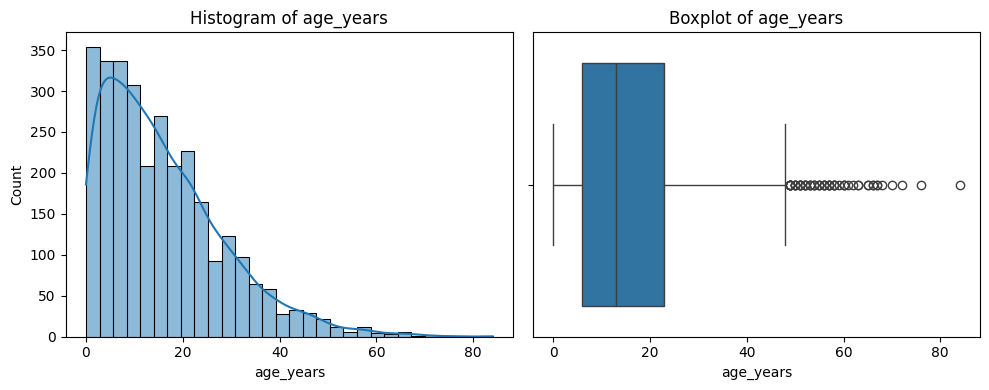

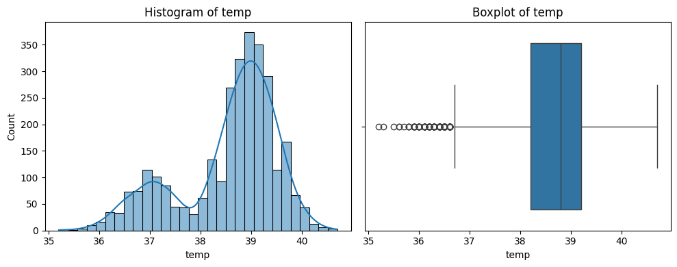

```python
columns_to_check = ["age_years", "temp"]

for col in columns_to_check:


    data_col = X[col]

    # Visual Inspection: Histogram and Q-Q Plot
    plt.figure(figsize=(10, 4))

    # Histogram
    plt.subplot(1, 2, 1)
    sns.histplot(data_col, kde=True, bins=30)
    plt.title(f"Histogram of {col}")

    # Q-Q Plot
    plt.subplot(1, 2, 2)
    sns.boxplot(x=data_col)
    plt.title(f"Boxplot of {col}")

    plt.tight_layout()
    plt.show()
```

##### Imputation Strategy

**Why Imputation is needed**

**For Discrete Columns (fever, chills, cough, aches, vomit):**

- These columns are binary (0/1), representing categorical data (e.g., yes/no).
- Justification - Mode is the most frequently occurring value in the column, making it the most logical choice for imputation in discrete variables.
- Conclusion - Filling missing values with the mode ensures consistency with the rest of the data.

```python
# Discrete columns: Fill NaN with mode
discrete_cols = ["fever", "chills", "cough", "aches", "vomit"]
for col in discrete_cols:
    X[col].fillna(X[col].mode()[0], inplace=True)

# Continuous columns: Fill NaN with median
continuous_cols = ["age_years", "temp"]
for col in continuous_cols:
    X[col].fillna(X[col].median(), inplace=True)

# Verify if all NaN values are filled
print("Missing values after imputation:")
print(X.isnull().sum())
```

```
Missing values after imputation:
age_years                                 0
wt_kg                                     0
ht_cm                                     0
bmi                                       0
ct_blood                                  0
fever                                     0
chills                                    0
cough                                     0
aches                                     0
vomit                                     0
temp                                      0
source_acquisition_Healthcare-acquired    0
dtype: int64
```

```python
df = disease_x_raw_df[required_features]
df.dropna(subset=["LOS"], inplace=True)
# df.dropna(inplace=True)
```

```python
from sklearn.model_selection import train_test_split

train_df, test_df = train_test_split(df, test_size=0.2, random_state=123)
train_df.head()
```

|  | age_years | wt_kg | ht_cm | bmi | ct_blood | fever | chills | cough | aches | vomit | temp | source_acquisition | LOS |
| --- | --- | --- | --- | --- | --- | --- | --- | --- | --- | --- | --- | --- | --- |
| 2326 | 12.0 | 48.0 | 114.0 | 36.934441 | 21.0 | yes | no | yes | no | yes | 39.3 | Community-acquired | 7.0 |
| 2351 | 25.0 | 62.0 | 155.0 | 25.806452 | 23.0 | yes | no | yes | no | yes | 39.8 | Healthcare-acquired | 18.0 |
| 300 | 16.0 | 31.0 | 107.0 | 27.076601 | 20.0 | no | no | no | no | yes | 36.6 | Healthcare-acquired | 18.0 |
| 2376 | 3.0 | 30.0 | 75.0 | 53.333333 | 23.0 | yes | no | no | no | yes | 38.8 | Community-acquired | 5.0 |
| 718 | 60.0 | 94.0 | 263.0 | 13.589903 | 19.0 | no | yes | yes | no | no | 38.0 | Healthcare-acquired | 24.0 |

```python
X_train = train_df.drop(columns=["LOS"])
X_test = test_df.drop(columns=["LOS"])
y_train = train_df["LOS"]
y_test = test_df["LOS"]
```

```python
from sklearn.pipeline import make_pipeline
from sklearn.preprocessing import StandardScaler
from sklearn.compose import make_column_transformer
from sklearn.preprocessing import OneHotEncoder, StandardScaler
from sklearn.impute import SimpleImputer


numeric_features = ["age_years", "wt_kg", "ht_cm", "bmi", "ct_blood", "temp"]
binary_features = ["fever", "chills", "cough", "aches", "vomit", "source_acquisition"]

# Define imputers
numeric_imputer = SimpleImputer(
    strategy="median"
)  # For numeric features, use mean imputation
binary_imputer = SimpleImputer(
    strategy="most_frequent"
)  # For binary features, use most frequent value (mode)

# Create the column transformer with imputation and preprocessing
preprocessor = make_column_transformer(
    (make_pipeline(numeric_imputer, StandardScaler()), numeric_features),
    (
        make_pipeline(binary_imputer, OneHotEncoder(drop="if_binary", dtype=int)),
        binary_features,
    ),
)
```

```python
df[numeric_features + ["LOS"]].corr("spearman").style.background_gradient()
```

|  | age_years | wt_kg | ht_cm | bmi | ct_blood | temp | LOS |
| --- | --- | --- | --- | --- | --- | --- | --- |
| age_years | 1.000000 | 0.876119 | 0.913220 | -0.773516 | 0.003322 | 0.019731 | -0.013348 |
| wt_kg | 0.876119 | 1.000000 | 0.874049 | -0.633414 | -0.008219 | 0.018258 | -0.006645 |
| ht_cm | 0.913220 | 0.874049 | 1.000000 | -0.901101 | 0.020988 | 0.017685 | -0.010415 |
| bmi | -0.773516 | -0.633414 | -0.901101 | 1.000000 | -0.033416 | -0.014054 | 0.018776 |
| ct_blood | 0.003322 | -0.008219 | 0.020988 | -0.033416 | 1.000000 | -0.031177 | -0.035636 |
| temp | 0.019731 | 0.018258 | 0.017685 | -0.014054 | -0.031177 | 1.000000 | 0.000779 |
| LOS | -0.013348 | -0.006645 | -0.010415 | 0.018776 | -0.035636 | 0.000779 | 1.000000 |

```python
from sklearn.dummy import DummyRegressor
from sklearn.model_selection import cross_validate

# Define regression metrics
regression_metrics = ["r2", "neg_mean_squared_error", "neg_mean_absolute_error"]

# The dummy model for regression
dr = DummyRegressor()

# Perform cross-validation and store results
cross_val_results = {}
cross_val_results["dummy"] = (
    pd.DataFrame(
        cross_validate(
            dr, X_train, y_train, return_train_score=True, scoring=regression_metrics
        )
    )
    .agg(["mean", "std"])
    .round(3)
    .T
)

# Show the train and validation scores
cross_val_results["dummy"]
```

|  | mean | std |
| --- | --- | --- |
| fit_time | 0.003 | 0.001 |
| score_time | 0.003 | 0.002 |
| test_r2 | -0.002 | 0.002 |
| train_r2 | 0.000 | 0.000 |
| test_neg_mean_squared_error | -129.552 | 12.755 |
| train_neg_mean_squared_error | -129.440 | 3.199 |
| test_neg_mean_absolute_error | -8.876 | 0.261 |
| train_neg_mean_absolute_error | -8.871 | 0.083 |

```python
from sklearn.linear_model import LinearRegression, Ridge, Lasso
from sklearn.pipeline import make_pipeline

# The linear regression model pipeline
linreg = make_pipeline(preprocessor, LinearRegression())

# The mean and std of the cross-validated scores for all metrics as a DataFrame
cross_val_results["linreg"] = (
    pd.DataFrame(
        cross_validate(
            linreg,
            X_train,
            y_train,
            return_train_score=True,
            scoring=regression_metrics,
        )
    )
    .agg(["mean", "std"])
    .round(3)
    .T
)

# Show the train and validation scores
cross_val_results["linreg"]
```

|  | mean | std |
| --- | --- | --- |
| fit_time | 0.026 | 0.006 |
| score_time | 0.008 | 0.002 |
| test_r2 | 0.118 | 0.020 |
| train_r2 | 0.128 | 0.005 |
| test_neg_mean_squared_error | -114.055 | 12.038 |
| train_neg_mean_squared_error | -112.904 | 3.008 |
| test_neg_mean_absolute_error | -8.264 | 0.313 |
| train_neg_mean_absolute_error | -8.216 | 0.100 |

```python
linreg.fit(X_train, y_train)
# Extract the LinearRegression model from the pipeline
linear_model = linreg.named_steps["linearregression"]

# Get the feature names from the preprocessor step
feature_names = linreg.named_steps["columntransformer"].get_feature_names_out()

# Create a DataFrame with predictors and coefficients
coefficients = pd.DataFrame(
    {"Predictor": feature_names, "Coefficient": linear_model.coef_}
).sort_values(by="Coefficient", ascending=False)

# Display the coefficients
print("Coefficients:")
print(coefficients)
```

```
Coefficients:
                                            Predictor   Coefficient
19                              pipeline-2__vomit_yes  9.011030e+09
18                               pipeline-2__vomit_no  9.011030e+09
21  pipeline-2__source_acquisition_Healthcare-acqu...  9.933830e+00
3                                     pipeline-1__bmi  4.996907e-01
2                                   pipeline-1__ht_cm  3.093414e-01
4                                pipeline-1__ct_blood  2.705514e-01
1                                   pipeline-1__wt_kg -6.516419e-02
0                               pipeline-1__age_years -2.837442e-01
5                                    pipeline-1__temp -3.649574e-01
12                               pipeline-2__cough_no -1.176234e+10
13                              pipeline-2__cough_yes -1.176234e+10
15                               pipeline-2__aches_no -1.207678e+10
16                              pipeline-2__aches_yes -1.207678e+10
10                             pipeline-2__chills_yes -1.287105e+10
9                               pipeline-2__chills_no -1.287105e+10
8                              pipeline-2__fever_None -1.389648e+10
14                             pipeline-2__cough_None -1.540276e+10
17                             pipeline-2__aches_None -1.540276e+10
20                             pipeline-2__vomit_None -1.540276e+10
11                            pipeline-2__chills_None -1.583403e+10
7                               pipeline-2__fever_yes -4.823966e+10
6                                pipeline-2__fever_no -4.823966e+10
```

**1. Create the Response Variable LOS (Length of Stay):**

- The Length of Stay (LOS) was calculated as the difference in days between date_outcome (discharge date or outcome date) and date_hospitalization.

**2. Build a Multivariate Linear Regression Model:**

Predictors Used:

age_years, wt_kg, ht_cm, bmi, ct_blood, fever, chills, cough, aches, vomit, temp, and source_acquisition (Healthcare-acquired/Community-acquired).

Data Preprocessing:

Model Construction:

- A multivariate linear regression model was trained using the preprocessed data.

**4. Interpret the Coefficient Estimate for the Predictor source_acquisition:**

- The coefficient for source_acquisition_Healthcare-acquired is approximately 9.93.
- Interpretation: Patients with healthcare-acquired infections stay, on average, 9.93 days longer in the hospital compared to those with community-acquired infections, holding all other predictors constant.

**5. Evaluate the Model Performance:**

- Dummy Model (Baseline):

  ```
    The dummy model provides a baseline for comparison:
    Test R²: -0.002 (indicates poor fit).
    Test Negative MSE: -129.55.
    Test Negative MAE: -8.87.
  ```

- Linear Regression Model:

  ```
    Performance metrics for the linear regression model:
    Test R²: 0.118 (modest improvement over the dummy model).
    Test Negative MSE: -114.05 (lower error compared to the dummy model).
    Test Negative MAE: -8.26 (lower absolute error compared to the dummy model).
  ```

Interpretation: The model explains 11.8% of the variance in LOS and provides better predictions than the baseline dummy model

What are the assumptions of the multivariate linear regression model used? How would you validate these assumptions, and do you find any violation of the assumptions? Please provide detailed steps for validating each assumption

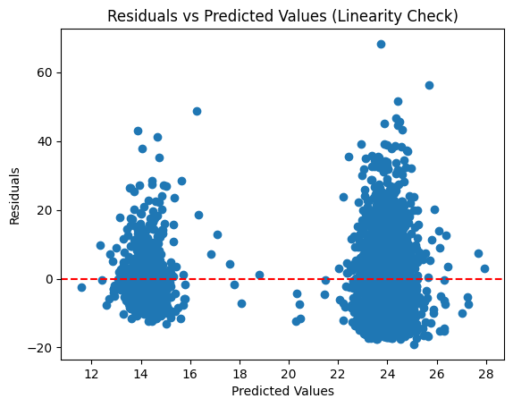

```
Durbin-Watson statistic: 1.9356
Breusch-Pagan Test: p-value=0.0010
```

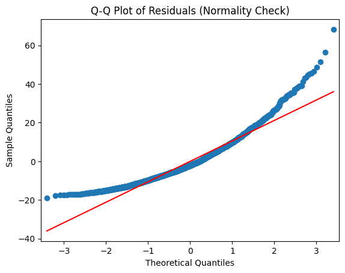

[output not shown]

```python
import statsmodels.api as sm
from statsmodels.stats.outliers_influence import variance_inflation_factor
from statsmodels.stats.diagnostic import het_breuschpagan
from scipy.stats import shapiro
from statsmodels.stats.stattools import durbin_watson

# Fit the regression model
X_with_const = sm.add_constant(X)  # Add constant for intercept
model = sm.OLS(y, X_with_const).fit()


predicted = model.predict(X_with_const)
residuals = y - predicted

plt.scatter(predicted, residuals)
plt.axhline(0, color="red", linestyle="--")
plt.title("Residuals vs Predicted Values (Linearity Check)")
plt.xlabel("Predicted Values")
plt.ylabel("Residuals")
plt.show()

# 2. Independence of Errors: Durbin-Watson test
dw_stat = durbin_watson(model.resid)
print(f"Durbin-Watson statistic: {dw_stat:.4f}")

# 3. Homoscedasticity: Breusch-Pagan test
bp_test = het_breuschpagan(residuals, X_with_const)
print(f"Breusch-Pagan Test: p-value={bp_test[1]:.4f}")

# 4. Normality of Residuals: Q-Q plot and Shapiro-Wilk test
sm.qqplot(residuals, line="s")
plt.title("Q-Q Plot of Residuals (Normality Check)")
plt.show()

shapiro_stat, shapiro_p = shapiro(residuals)
print(f"Shapiro-Wilk Test: Statistic={shapiro_stat:.4f}, p-value={shapiro_p:.4f}")

# 5. Multicollinearity: VIF
vif_data = pd.DataFrame(
    {
        "Variable": X.columns,
        "VIF": [
            variance_inflation_factor(X_with_const.values, i + 1)
            for i in range(X_with_const.shape[1] - 1)
        ],
    }
)
print("Variance Inflation Factors (VIF):")
print(vif_data)
```

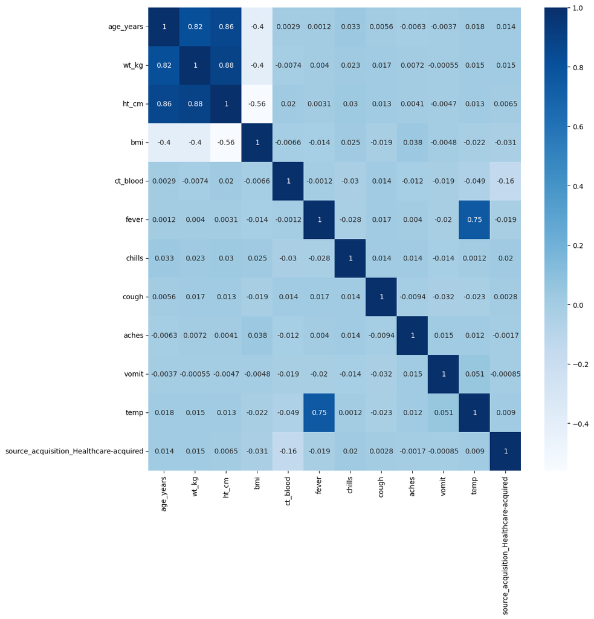

```python
fig = plt.figure(figsize=(12, 12))
sns.heatmap(X.corr(), annot=True, cmap="Blues")
plt.show()
```

What other methods, models, or techniques could you use to improve the performance of the model? Please provide detailed explanations of the method(s), model(s), or technique(s) you would consider, and explain why they might improve the model performance

```python
# Ridge Regression pipeline
ridge = make_pipeline(preprocessor, Ridge(alpha=1.0))  # Adjust alpha as needed
cross_val_results["ridge"] = (
    pd.DataFrame(
        cross_validate(
            ridge, X_train, y_train, return_train_score=True, scoring=regression_metrics
        )
    )
    .agg(["mean", "std"])
    .round(3)
    .T
)

# Lasso Regression pipeline
lasso = make_pipeline(
    preprocessor, Lasso(alpha=0.1, max_iter=10000)
)  # Adjust alpha and max_iter as needed
cross_val_results["lasso"] = (
    pd.DataFrame(
        cross_validate(
            lasso, X_train, y_train, return_train_score=True, scoring=regression_metrics
        )
    )
    .agg(["mean", "std"])
    .round(3)
    .T
)
```

```python
from lightgbm import LGBMRegressor
from xgboost import XGBRegressor
from sklearn.ensemble import RandomForestRegressor

# Random Forest pipeline
pipe_rf = make_pipeline(preprocessor, RandomForestRegressor(random_state=123))

# XGBoost pipeline
pipe_xgb = make_pipeline(
    preprocessor,
    XGBRegressor(
        random_state=123, verbosity=0
    ),  # Remove eval_metric since it's specific to classification
)

# LightGBM pipeline
pipe_lgbm = make_pipeline(preprocessor, LGBMRegressor(random_state=123))

# Store regression pipelines
regressors = {
    "random forest": pipe_rf,
    "XGBoost": pipe_xgb,
    "LightGBM": pipe_lgbm,
}

for name, model in regressors.items():
    cross_val_results[name] = (
        pd.DataFrame(
            cross_validate(
                model,
                X_train,
                y_train,
                return_train_score=True,
                scoring=regression_metrics,
            )
        )
        .agg(["mean", "std"])
        .round(3)
        .T
    )
pd.concat(cross_val_results, axis=1)
```

[output not shown]

|  | dummy mean | dummy std | linreg mean | linreg std | ridge mean | ridge std | lasso mean | lasso std | random forest mean | random forest std | XGBoost mean | XGBoost std | LightGBM mean | LightGBM std |
| --- | --- | --- | --- | --- | --- | --- | --- | --- | --- | --- | --- | --- | --- | --- |
| fit_time | 0.003 | 0.001 | 0.026 | 0.006 | 0.031 | 0.011 | 0.026 | 0.009 | 3.452 | 0.148 | 0.804 | 1.452 | 0.169 | 0.142 |
| score_time | 0.003 | 0.002 | 0.008 | 0.002 | 0.013 | 0.005 | 0.009 | 0.004 | 0.024 | 0.006 | 0.010 | 0.002 | 0.009 | 0.001 |
| test_r2 | -0.002 | 0.002 | 0.118 | 0.020 | 0.118 | 0.020 | 0.121 | 0.021 | 0.035 | 0.040 | -0.141 | 0.052 | 0.001 | 0.025 |
| train_r2 | 0.000 | 0.000 | 0.128 | 0.005 | 0.128 | 0.005 | 0.125 | 0.005 | 0.863 | 0.002 | 0.923 | 0.002 | 0.573 | 0.003 |
| test_neg_mean_squared_error | -129.552 | 12.755 | -114.055 | 12.038 | -114.056 | 12.036 | -113.733 | 12.336 | -124.582 | 10.780 | -147.038 | 9.668 | -128.916 | 10.759 |
| train_neg_mean_squared_error | -129.440 | 3.199 | -112.904 | 3.008 | -112.904 | 3.007 | -113.226 | 3.047 | -17.798 | 0.628 | -10.015 | 0.389 | -55.245 | 1.773 |
| test_neg_mean_absolute_error | -8.876 | 0.261 | -8.264 | 0.313 | -8.265 | 0.313 | -8.258 | 0.327 | -8.683 | 0.265 | -9.422 | 0.223 | -8.785 | 0.255 |
| train_neg_mean_absolute_error | -8.871 | 0.083 | -8.216 | 0.100 | -8.217 | 0.099 | -8.236 | 0.098 | -3.244 | 0.052 | -2.266 | 0.062 | -5.676 | 0.078 |

Key Metrics to Consider:

- Test R^2:Higher values are better, indicating the model explains more variance in the test set.
- Test Negative Mean Squared Error (MSE):Less negative values are better, indicating lower errors.
- Test Negative Mean Absolute Error (MAE):Less negative values are better, indicating lower average errors.
- Overfitting :The gap between train and test metrics should be minimal. A large gap indicates overfitting.

Evaluation:

**Best Model: Lasso Regression**